# EP08

Grupo 5

2025-05-05

# Actividades

Como habíamos visto a comienzos del semestre, la Encuesta de Caracterización Socioeconómica Nacional (Casen) es realizada por el Ministerio de Desarrollo Social de forma periódica para conocer la situación de los hogares chilenos con relación a aspectos demográficos, de educación, salud, vivienda, trabajo e ingresos. Es la principal fuente de información para estimar la magnitud de la pobreza y la distribución del ingreso en el país.

En el contexto de este estudio, realizaremos las siguientes actividades:

1. Obtener los datos, disponibles en el archivo “EP08 Datos CASEN 2017.csv”, desde el directorio compartido correspondiente.
2. Copiar los enunciados de las preguntas asignadas como comentarios de un script R.
3. Familiarizarse con los datos entregados y proponer una pregunta de investigación interesante (= no trivial) de acuerdo a lo solicitado en el enunciado de cada pregunta.
4. Enunciar las hipótesis nula y alternativa que permitan responder las preguntas de investigación planteadas.
5. Argumentar o escribir código R para verificar que no se cumplen las condiciones para pruebas paramétricas con validez para el caso en estudio.
6. Escribir código R para realizar los análisis estadísticos solicitados para cada caso.
7. Redactar la respuesta a la pregunta de investigación planteada en base a los resultados del análisis realizado.

# Preguntas propuestas

1. La frecuencia de personas mayores de 80 años en la región metropolitana ¿Es similar en las demás regiones?
2. La edad promedio de las personas mayores de 18 años ¿Es similar en los estados de soltero, casado y viudo?

# Pregunta 1

La frecuencia de personas mayores de 80 años en la región metropolitana ¿Es similar en las demás regiones?

### Desarrollo de actividades para resolver la pregunta:

1). Obtencion de datos e hipótesis a contrastar:

```r
# Carga de datos
casen <- read.csv("EP08 Datos CASEN 2017.csv")

# Limpiar y clasificar personas por región y edad
casen_filtrado <- casen %>%
  filter(!is.na(edad), edad >= 0) %>%
  mutate(
    grupo_region= if_else(region == "Región Metropolitana de Santiago",
                           "Metropolitana", "Resto"),
    anciano = edad >= 80
  )

# Obtener IDs únicos de hogares presentes en los datos filtrados
ids_todos <- unique(casen_filtrado$id.vivienda)

# Fijar semilla y muestrear 120 hogares
set.seed(777)
ids_muestra <- sample(ids_todos, size = 120)

# Filtrar las personas pertenecientes a esos hogares seleccionados
muestra <- casen_filtrado %>%
  filter(id.vivienda %in% ids_muestra) %>%
  select(id.vivienda, grupo_region, edad, anciano)
```

Las hipótesis a contrastar son:

- **Hipótesis nula (H₀): La frecuencia de personas mayores de 80 años en la región metropolitana es similar en las demás regiones.**
- **Hipótesis alternativa (Ha): La frecuencia de personas mayores de 80 años en la región metropolitana no es similar en las demás regiones.**

Resumen de las muestras tomadas, teniendo en cuenta la cantidad de personas tomadas, de ancianos y de su proporción en la Región Metropolitana y del resto de regiones. Seguidamente se incluye la diferencia observada en la proporción de personas mayores de 80 años entre la Región Metropolitana y el resto del país. Para ello, se estimó la proporción de personas ≥80 años en cada grupo y se obtuvo su diferencia (prop_dif), que corresponde al estadístico observado que será contrastado mediante permutaciones.

```r
# Resumen rápido
muestra %>%
  group_by(grupo_region) %>%
  summarise(
    personas  = n(),
    ancianos  = sum(anciano),
    proporcion = mean(anciano)
  )
```

```
## # A tibble: 2 × 4
##   grupo_region  personas ancianos proporcion
##   <chr>            <int>    <int>      <dbl>
## 1 Metropolitana       10        4     0.4
## 2 Resto              138        5     0.0362
```

```r
prop_dif <- diff(
  muestra %>%
    group_by(grupo_region) %>%
    summarise(prop = mean(anciano)) %>%
    pull(prop)
)
print(prop_dif)
```

```
## [1] -0.3637681
```

2). Se crea una gran cantidad P de permutaciones a partir de las muestras originales, usando muestreo sin reposición sobre la muestra combinada, además de obtener el p-value.

También se incluye un histograma de la distribución nula obtenida mediante permutaciones, el cual permitirá visualizar la posición del estadístico observado respecto a dicha distribución.

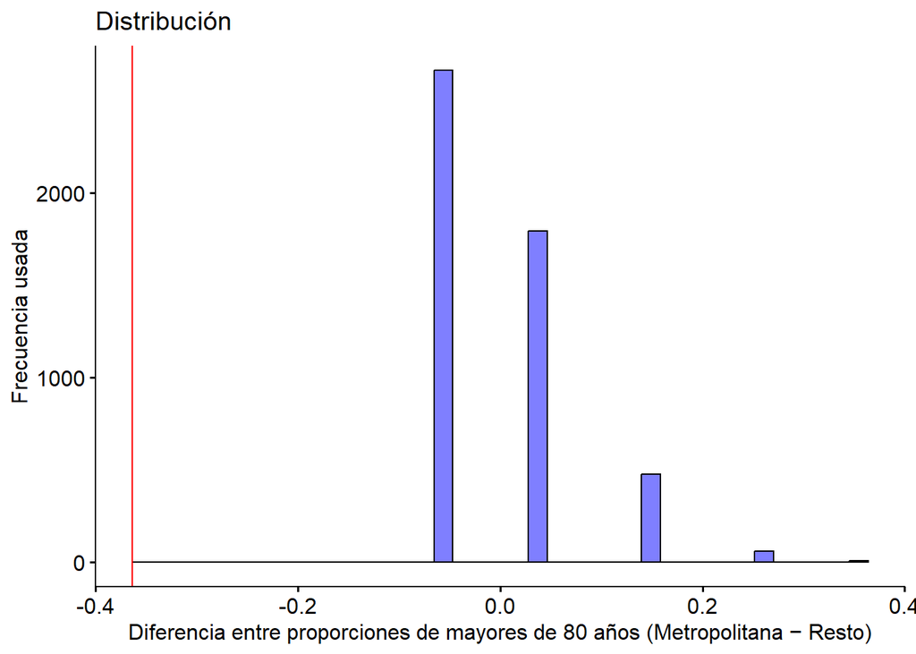

```r
set.seed(777)
# Permutaciones
B <- 4999
perm_diffs <- replicate(B, {
  grupo_region_perm <- sample(muestra$grupo_region)
  mean(muestra$anciano[grupo_region_perm == "Metropolitana"]) -
    mean(muestra$anciano[grupo_region_perm == "Resto"])
})

p1 <- gghistogram(
  data.frame(perm_diffs), "perm_diffs",
  bins = 40,
  fill = "blue",
  title = "Distribución",
  xlab = "Diferencia entre proporciones de mayores de 80 años (Metropolitana − Resto)",
  ylab = "Frecuencia usada"
)
p1 <- p1 + geom_vline(xintercept = prop_dif, colour = "red")
print(p1)
```

```r
# Valor‑p bilateral
p_value <- mean(abs(perm_diffs) >= abs(prop_dif))
print(p_value)
```

```
## [1] 0.00140028
```

Conclusión:

Como el p-valor es menor al nivel de significancia (0.0014 < 0.05), se rechaza la hipótesis nula, por ende, con un 95% de nivel de confianza podemos decir que la frecuencia de personas mayores de 80 años en la región metropolitana no es similar en las demás regiones.

## Pregunta 2

La edad promedio de las personas mayores de 18 años ¿Es similar en los estados de soltero, casado y viudo?

- **Hipótesis nula (H₀): Las medias poblacionales de edad son iguales en los tres grupos de estado civil.**
- **Hipótesis alternativa (Ha): Al menos una de las medias poblacionales de edad difiere entre los grupos.**

### Desarrollo de actividades para resolver la pregunta:

Se utilizará bootstrapping con remuestras en conjunto con ANOVA para contestar la pregunta planteada

1). Obtencion de datos e hipótesis a contrastar:

```r
# Cargar sólo las variables necesarias
casen <- read_csv("EP08 Datos CASEN 2017.csv", col_types = cols()) |>
  select(id.vivienda, edad, ecivil) |>
  filter(!is.na(edad), edad > 18)           # personas >18 años

niveles_ecivil <- c("Soltero(a)", "Casado(a)", "Viudo(a)")

casen <- casen |>
  filter(ecivil %in% niveles_ecivil)


n_hogares <- 250
set.seed(101)
ids_todos <- unique(casen$id.vivienda)
ids_muestra2 <- sample(ids_todos, n_hogares)

muestra2 <- casen |>
  filter(id.vivienda %in% ids_muestra2) |>
  mutate(ecivil = factor(ecivil, levels = niveles_ecivil))

leveneTest(edad ~ ecivil, data = muestra2)
```

```
## Levene's Test for Homogeneity of Variance (center = median)
##        Df F value Pr(>F)
## group   2  2.0714 0.1279
##       284
```

Como el p-valor del test de Levene es mayor al nivel de significancia (p>0.05), no se rechaza la hipótesis nula de homogeneidad de varianzas, por lo que se puede continuar con el análisis de ANOVA, con énfasis en el valor F observado.

```r
# Estadístico observado
muestra2_anova <- muestra2 |>
  mutate(id = factor(1:n())) |>
  select(id, edad, ecivil)

resultado <- ezANOVA(
  data = muestra2_anova,
  dv = edad,
  wid = id,
  between = ecivil,
  type = 2
)
```

```
## Coefficient covariances computed by hccm()
```

```r
print(resultado)
```

```
## $ANOVA
##   Effect DFn DFd      F            p p<.05       ges
## 1 ecivil   2 284 46.475 3.458698e-18     * 0.2465844
##
## $`Levene's Test for Homogeneity of Variance`
##   DFn DFd      SSn      SSd        F         p p<.05
## 1   2 284 409.5751 28077.73 2.071381 0.1279113
```

```r
F_obs=resultado$ANOVA$F
print(F_obs)
```

```
## [1] 46.475
```

Con el fin de simular correctamente la hipótesis nula de igualdad de medias entre los grupos de estado civil, se realizo un reescalado de las edades dentro de cada grupo. Dicho procedimiento consistió en ajustar los valores de edad para que cada grupo tuviera la misma media y desviación estándar globales, manteniendo al mismo tiempo la estructura relativa interna de cada grupo. De esta forma, se genera un conjunto de datos artificial donde las diferencias entre grupos han sido eliminadas, permitiendo aplicar el método bootstrap de manera válida para contrastar la hipótesis nula.

```r
grupos <- muestra2 |>
  group_by(ecivil) |>
  summarise(
    media = mean(edad),
    sd = sd(edad)
  ) |>
  as.data.frame()

grupos
```

```
##       ecivil    media       sd
## 1 Soltero(a) 43.27000 17.55733
## 2  Casado(a) 54.24648 15.51535
## 3   Viudo(a) 70.68889 13.61954
```

```r
# Calcular media y desviación estándar global
media_gral <- mean(muestra2$edad)
sd_gral <- sd(muestra2$edad)


solteros <- muestra2 %>%
  filter(ecivil == "Soltero(a)") %>%
  mutate(edad = media_gral +
           (edad - mean(edad)) * (sd_gral / sd(edad)))

casados <- muestra2 %>%
  filter(ecivil == "Casado(a)") %>%
  mutate(edad = media_gral +
           (edad - mean(edad)) * (sd_gral / sd(edad)))

viudos <- muestra2 %>%
  filter(ecivil == "Viudo(a)") %>%
  mutate(edad = media_gral +
           (edad - mean(edad)) * (sd_gral / sd(edad)))

# Unir todos los grupos reescalados
muestra2_Z <- bind_rows(solteros, casados, viudos)
```

Ahora se generan las muestras bootstrap para cada grupo. Obteniendo valores de F para cada una de las muestras generadas, además se incluye un gráfico de la distribución de los valores de F obtenidos a partir de las muestras bootstrap, junto con el valor observado del estadístico F para obtener una comparación visual.

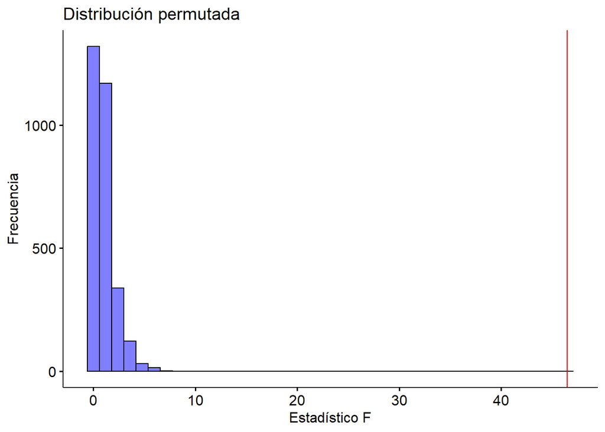

```r
# Generacion de muestras bootstrap
set.seed(573)
B <- 2999

solteros <- muestra2_Z %>%
  filter(ecivil == "Soltero(a)") %>%
  select(edad, ecivil)

casados <- muestra2_Z %>%
  filter(ecivil == "Casado(a)") %>%
  select(edad, ecivil)

viudos <- muestra2_Z %>%
  filter(ecivil == "Viudo(a)") %>%
  select(edad, ecivil)


re_sol <- lapply(1:B, function(i) sample(nrow(solteros), replace = TRUE))
re_cas <- lapply(1:B, function(i) sample(nrow(casados),  replace = TRUE))
re_viu <- lapply(1:B, function(i) sample(nrow(viudos),  replace = TRUE))


# Función bootstrap para calcular el estadístico F
bootstrap_f <- function(b) {
  datos_b <- rbind(
    solteros[re_sol[[b]], ],
    casados[re_cas[[b]], ],
    viudos[re_viu[[b]], ]
  )

  modelo <- aov(edad ~ ecivil, data = datos_b)
  car::Anova(modelo, type = 2)$`F value`[1]
}



boot_F <- sapply(1:B, bootstrap_f)


p2 <- gghistogram(data.frame(boot_F), x = "boot_F",
                  title = "Distribución permutada",
                  xlab = "Estadístico F", ylab = "Frecuencia",
                  bins = 40, fill = "blue")
p2 <- p2 + geom_vline(xintercept = F_obs, colour="red")
print(p2)
```

En el gráfico,la línea roja vertical indica el valor de F observado en los datos reales. Dado que este valor se encuentra claramente fuera del rango esperado bajo la hipótesis nula, se estima que la diferencia observada entre los grupos es estadísticamente significativa.

Ahora se realizará el contraste de hipótesis, calculando el valor crítico y el p-valor empírico bootstrap. El valor crítico se obtiene a partir del percentil 95 de la distribución nula generada por el bootstrap, mientras que el p-valor empírico se calcula como la proporción de valores de F en la distribución nula que son mayores que el valor observado:

```r
F_crit <- quantile(boot_F, 0.95)
num2 <- sum(boot_F > F_obs)
p_val2 <- (num2 + 1) / (B + 1)

print(F_crit)
```

```
##      95%
## 3.121253
```

```r
print(p_val2)
```

```
## [1] 0.0003333333
```

Como resultado, se obtuvo un valor crítico F igual a 3.12 (percentil 95% de la distribución nula), mientras que el valor del estadístico F observado fue superior a dicho umbral. Por otro lado el p-valor fue menor al nivel de significancia (p < 0.05), por lo tanto, se concluye con un 95% de confianza que existen diferencias significativas en la edad promedio entre al menos dos de los grupos de estado civil analizados (soltero, casado y viudo).

## POST-HOC

En este caso, el resultado de la prueba fue estadísticamente significativo (p < 0.05), se realiza entonces el análisis post-hoc con fines académicos, para explorar posibles diferencias y ejercitar la metodología. Utilizando la diferencia de las medias como nuevo estadístico de interés.

```r
dif_obs_SC <- mean(solteros$edad) - mean(casados$edad)
dif_obs_SV <- mean(solteros$edad) - mean(viudos$edad)
dif_obs_CV <- mean(casados$edad)  - mean(viudos$edad)

get_dif_medias <- function(grupo1, grupo2, indices1, indices2) {
  media1 <- mean(grupo1[["edad"]][indices1])
  media2 <- mean(grupo2[["edad"]][indices2])
  media1 - media2
}

# Comparación Solteros - Casados
boot_dif_SC <- sapply(1:B, function(b) {
  get_dif_medias(solteros, casados, re_sol[[b]], re_cas[[b]])
})

# Comparación Solteros - Viudos
boot_dif_SV <- sapply(1:B, function(b) {
  get_dif_medias(solteros, viudos, re_sol[[b]], re_viu[[b]])
})

# Comparación Casados - Viudos
boot_dif_CV <- sapply(1:B, function(b) {
  get_dif_medias(casados, viudos, re_cas[[b]], re_viu[[b]])
})


# Diferencia observada y p-valor empírico bootstrap (dos colas)
dif_obs_SC <- mean(solteros$edad) - mean(casados$edad)
p_SC <- mean(abs(boot_dif_SC) >= abs(dif_obs_SC))
dif_obs_SV <- mean(solteros$edad) - mean(viudos$edad)
p_SV <- mean(abs(boot_dif_SV) >= abs(dif_obs_SV))
dif_obs_CV <- mean(casados$edad) - mean(viudos$edad)
p_CV <- mean(abs(boot_dif_CV) >= abs(dif_obs_CV))
```

Para complementar el análisis post-hoc, se presentan a continuación gráficos de densidad que muestran la distribución de las diferencias de medias generadas mediante bootstrap para cada par de grupos.

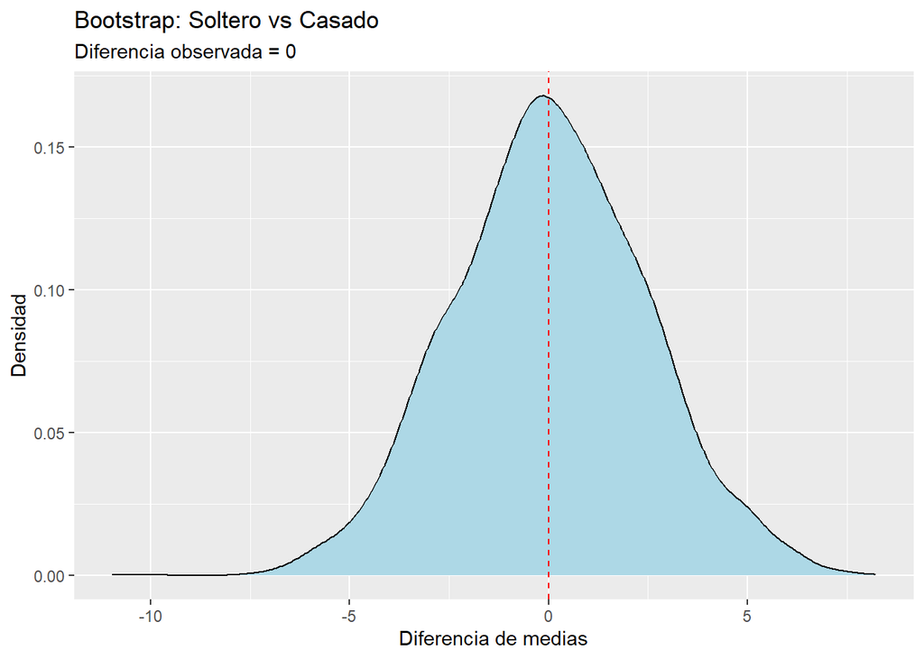

```r
# 1. Soltero vs Casado
ggplot(data.frame(diff = boot_dif_SC), aes(x = diff)) +
  geom_density(fill = "lightblue") +
  geom_vline(xintercept = dif_obs_SC, color = "red", linetype = "dashed") +
  labs(title = "Bootstrap: Soltero vs Casado",
       subtitle = paste("Diferencia observada =", round(dif_obs_SC, 2)),
       x = "Diferencia de medias", y = "Densidad")
```

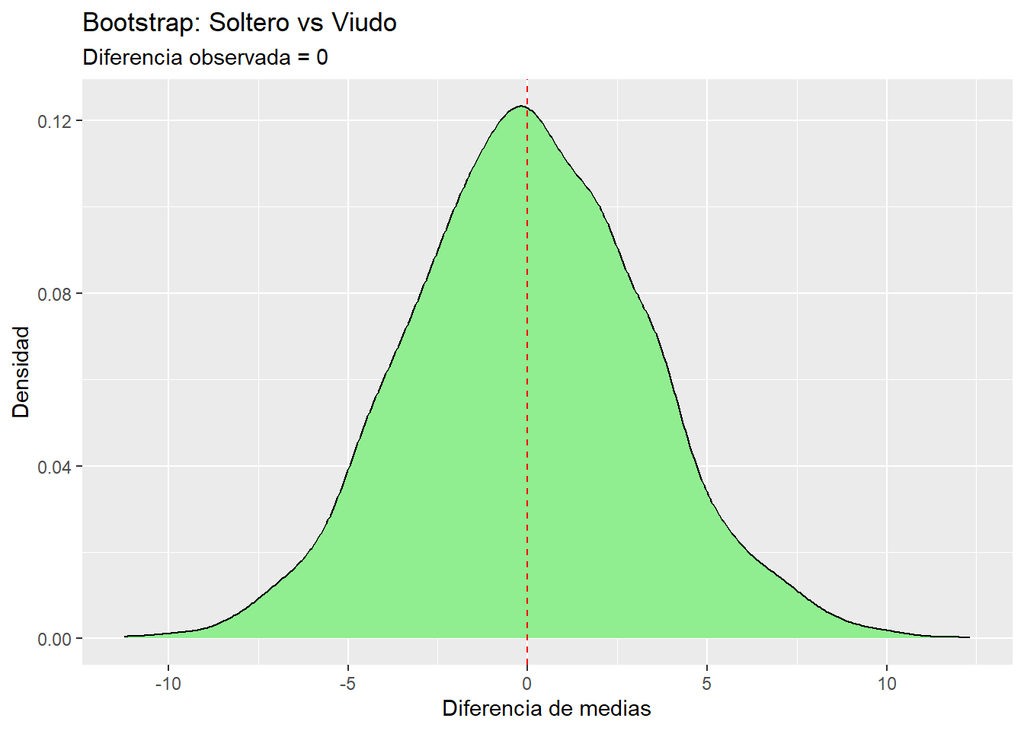

```r
# 2. Soltero vs Viudo
ggplot(data.frame(diff = boot_dif_SV), aes(x = diff)) +
  geom_density(fill = "lightgreen") +
  geom_vline(xintercept = dif_obs_SV, color = "red", linetype = "dashed") +
  labs(title = "Bootstrap: Soltero vs Viudo",
       subtitle = paste("Diferencia observada =", round(dif_obs_SV, 2)),
       x = "Diferencia de medias", y = "Densidad")
```

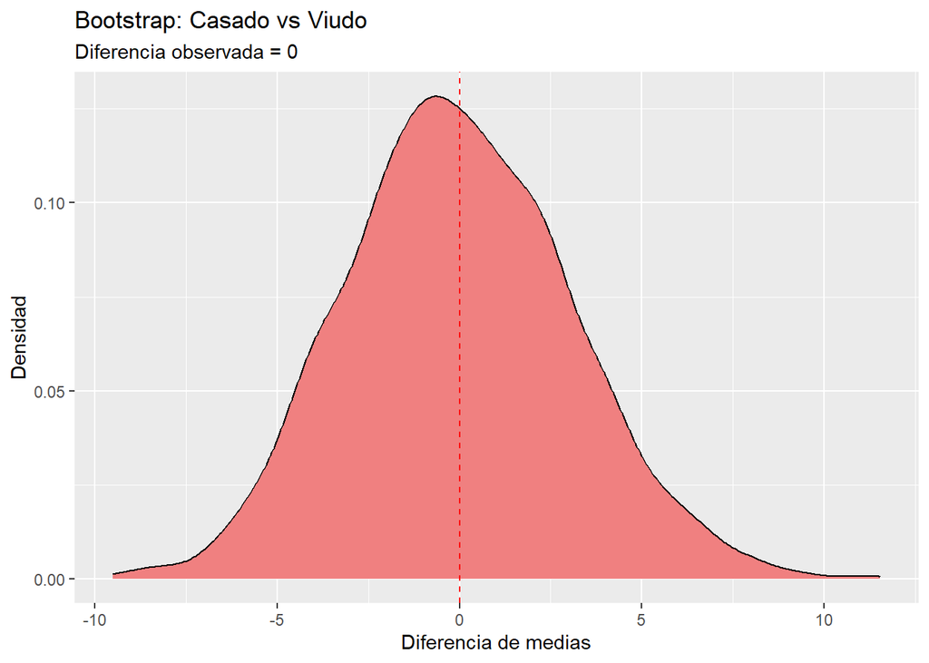

```r
# 3. Casado vs Viudo
ggplot(data.frame(diff = boot_dif_CV), aes(x = diff)) +
  geom_density(fill = "lightcoral") +
  geom_vline(xintercept = dif_obs_CV, color = "red", linetype = "dashed") +
  labs(title = "Bootstrap: Casado vs Viudo",
       subtitle = paste("Diferencia observada =", round(dif_obs_CV, 2)),
       x = "Diferencia de medias", y = "Densidad")
```

```r
data.frame(
  Comparación = c("Soltero - Casado", "Soltero - Viudo", "Casado - Viudo"),
  Diferencia_Obs = c(dif_obs_SC, dif_obs_SV, dif_obs_CV),
  `IC 2.5%` = c(quantile(boot_dif_SC, 0.025),
               quantile(boot_dif_SV, 0.025),
               quantile(boot_dif_CV, 0.025)),
  `IC 97.5%` = c(quantile(boot_dif_SC, 0.975),
                quantile(boot_dif_SV, 0.975),
                quantile(boot_dif_CV, 0.975)),
  `p-valor` = c(p_SC, p_SV, p_CV)
)
```

```
##        Comparación Diferencia_Obs   IC.2.5. IC.97.5. p.valor
## 1 Soltero - Casado   7.105427e-15 -4.654681 4.939954       1
## 2  Soltero - Viudo  -7.105427e-15 -6.264458 6.746186       1
## 3   Casado - Viudo  -1.421085e-14 -5.819334 6.328245       1
```